# Multiple instance based deep classification for mass spectrometry imaging

# 5 Multiple instance based training

```r
micnn <- multipleInstanceCNN(mse_train, mse_train$tlabel, model_name = 'bladder_classifier2', method = 'multiple_instance', num_epochs = 10)
```

```
## fitting multiple instance convolutional network...
```

Summarize the trained model.

```r
summary(micnn)
```

```
## DNN classification:
##
##  Classification on 2 classes: 0 1
##  method = multiple_instance
##  epochs = 10
##
##       classifier_name            method  Accuracy Sensitivity Specificity
## 1 bladder_classifier2 multiple_instance 0.8263205   0.9585366   0.7496464
```

Plot the predicted class.

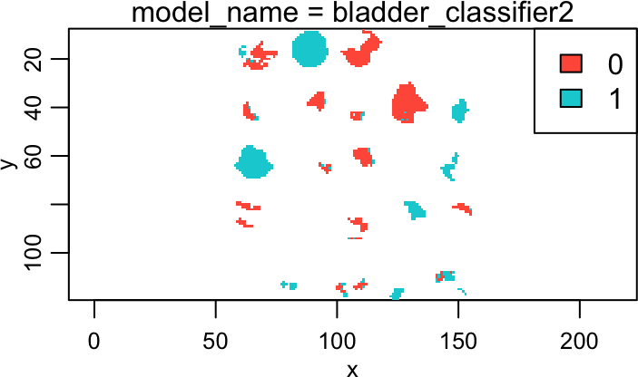

```r
image(micnn)
```

We can use `predict()` to predict the testing data using the trained model and visualize the results.

```r
micnn_predict <- predict(micnn, newx = mse_test, newy = mse_test$plabel)
```

```
## predicting usingbladder_classifier2
```

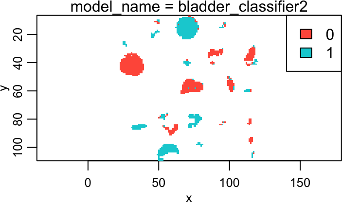

```r
image(micnn_predict)
```

Use `summary()` to summarize the performance of the trained model on testing data if the testing data has ground-truth labels.

```r
summary(micnn_predict)
```

```
## DNN classification:
##
##  Classification on 2 classes: 0 1
##  method = multiple_instance
##  epochs = 10
##
##       classifier_name            method  Accuracy Sensitivity Specificity
## 1 bladder_classifier2 multiple_instance 0.9325095   0.9500924   0.9138943
```

Use `topFeatures()` to rank mass features by weights of explanability.

```r
micnn_top <- topFeatures(micnn, train = train, test = test, method = 'lime', n = 10)
```

```
## [1] "from classification import explain\nfeature = explain.explain(bladder_classifier2, train_data = r.train, test_data = r.test, num_features = 10, instance_id = 1 )\n"
```

```r
micnn_top
```

```
## Top-ranked features:
##                                   mz        coef
## 1         mz944.546352070327 <= 8.27 -0.20594110
## 2         mz1105.62622570369 <= 1.35  0.11282772
## 3  1.12 < mz1095.55313989056 <= 2.72  0.06283540
## 4  1.11 < mz1095.65996850358 <= 2.65  0.04880565
## 5         mz945.550086643276 <= 4.92 -0.04806707
## 6  1.79 < mz868.469772330268 <= 6.17  0.04449096
## 7         mz1106.63706172667 <= 1.15  0.03997604
## 8  1.44 < mz943.570200031283 <= 4.16 -0.03628641
## 9          mz1269.12852467496 > 0.06  0.03010191
## 10         mz1106.91923486407 > 0.06 -0.02602733
```

Plot bar plot of the top features. Refer to the plot of `micnn_supervised_top` for interpreting the plot.

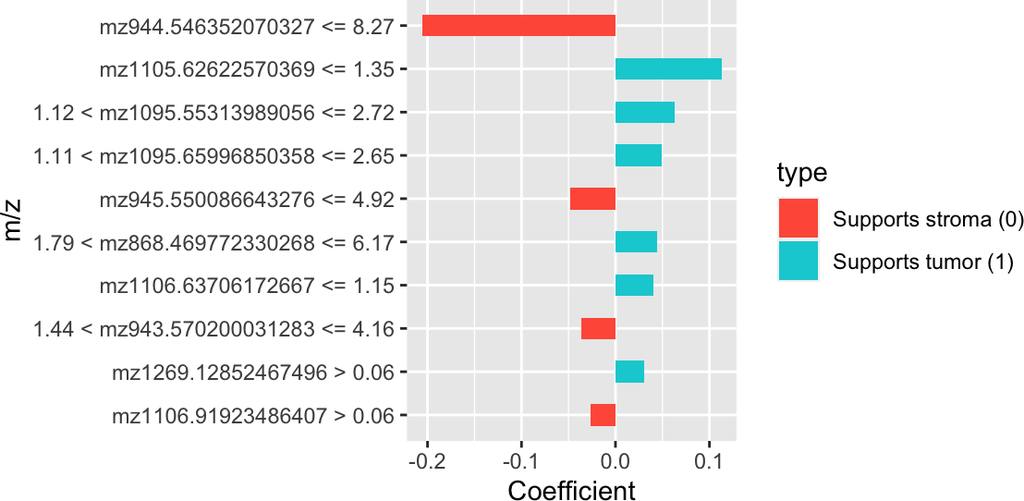

```r
plot(micnn_top)
```

# 6 Access the results data

We can access the predictions using `resultData()’. The predictions contain the predicted classes and probabilities of each class.

```r
predicted_class <- resultData(micnn_predict)[[1]]$class
predicted_prob <- resultData(micnn_predict)[[1]]$probability
```

use it to subset the MSI data. Subsetting the pixels predicted as 0:

```r
mse_sub = mse_test[, predicted_class == 0]
mse_sub
```

```
## An object of class 'MSContinuousImagingExperiment'
##   <979 feature, 558 pixel> imaging dataset
##     imageData(1): intensity
##     featureData(0):
##     pixelData(5): plabel diagnosis invasiveness sample tlabel
##     metadata(2): files name
##     processing complete(6): smoothSignal reduceBaseline ... peakBin normalize
##     processing pending(0):
##     run(1): TMA1
##     raster dimensions: 96 x 98
##     coord(2): x = 23..118, y = 7..104
##     mass range:  800.4447 to 2280.0257
##     centroided: TRUE
```

Subsetting the pixels predicted as 1:

```r
mse_sub = mse_test[,predicted_class == 1]
mse_sub
```

```
## An object of class 'MSContinuousImagingExperiment'
##   <979 feature, 494 pixel> imaging dataset
##     imageData(1): intensity
##     featureData(0):
##     pixelData(5): plabel diagnosis invasiveness sample tlabel
##     metadata(2): files name
##     processing complete(6): smoothSignal reduceBaseline ... peakBin normalize
##     processing pending(0):
##     run(1): TMA1
##     raster dimensions: 96 x 102
##     coord(2): x = 25..120, y = 8..109
##     mass range:  800.4447 to 2280.0257
##     centroided: TRUE
```

We can visualize the predicted probabilities of the subset of pixels predicted as 1. In the figure, higher probability (lighter color) indicates that the pixel is more likely to belong to group 1 than group 0.

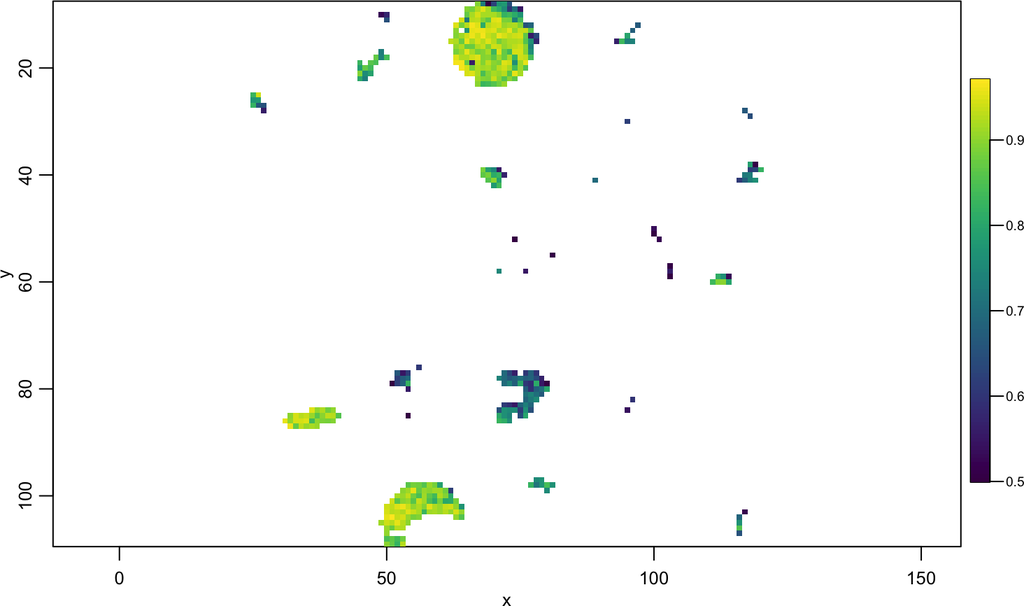

```r
image(mse_sub, predicted_prob[predicted_class==1]~x*y)
```

# 7 Cross validation

When there are not enough samples to split into training and testing data, unlike reporting the accuracy on the testing data, we can report the average accuracy of cross validation. First, we create the x-fold (5-fold for example) split of the data:

```r
set.seed(1)
folds <- split(unique(mse_train$sample), sample(20, 5))
fold_dataframe <- data.frame(unlist(folds), c(rep(1, 4), rep(2, 4), rep(3, 4), rep (4,4), rep(5,4)))
colnames(fold_dataframe) <- c("patient", "folds")
rownames(fold_dataframe) <- NULL

p_df <- data.frame(mse_train$sample)
colnames(p_df) <- 'patient'
joint_df <- merge(fold_dataframe, p_df, by = 'patient')

mse_train$folds <- joint_df$folds

table(mse_train$folds)
```

```
##
##   1   2   3   4   5
## 164 361 215 251 126
```

Then we fit CNN models for different folds and summarize the accuracy, sensitivity, and specificty:

```r
micnn_cv <- crossValidate(mse_train, mse_train$plabel,
                          .fun="multipleInstanceCNN",
                          .fold=mse_train$folds)
```

```
## fitting fully supervised convolutional network...
```

```
## predicting usingbladder_classifier1
```

```
## fitting fully supervised convolutional network...
```

```
## predicting usingbladder_classifier1
```

```
## fitting fully supervised convolutional network...
```

```
## predicting usingbladder_classifier1
```

```
## fitting fully supervised convolutional network...
```

```
## predicting usingbladder_classifier1
```

```
## fitting fully supervised convolutional network...
```

```
## predicting usingbladder_classifier1
```

```r
summary(micnn_cv)
```

```
## Cross validation:
##
##  Classification on 2 classes: 0 1
##  Summarized 5 folds: 1 2 3 4 5
##
##            model_name  Accuracy Sensitivity Specificity
## 1 bladder_classifier1 0.8969156   0.8651998   0.8729623
```